# NHS Wales Data

Mark Baber

2021

# Web Scraping NHS Wales

This report will go over the steps taken to web scrape data from an NHS Wales website. This involves:

- Downloading the files into rstudio
- Carrying out some EDA
- Plotting the data
- Feature Extraction/Creation

## 0 - Set a Working Directory

Usually when working within R, I start by creating a new folder and a project file, this can be done via the gui (top right of rstudio) or via the console.

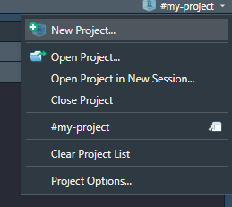

Create Project Via RStudio

```r
getwd()
```

```
## [1] "C:/Users/markb/OneDrive/university/msc-work/msc-project-data-science/#my-project"
```

Whilst I often switch between operating systems (Linux & Windows) this isn’t always an ideal way of setting the project, especially when using online cloud storage. This works much better via Git && Github.

## 1 - EDA

Firstly, when working with scripts and data science coding, it is usually very helpful to set the seed, for reproducibility.

For the seed I set it as my student number from USW - but can be anything.

```r
# 17076749
set.seed(17076749)
```

Next would be to set the libraries which could be useful throughout this report, most jobs within r can be done with the base set libraries, but sometimes it’s fun to explore other methods which make some tasks a lot easier/faster. These packages aren’t set in stone, and are dynamic for this report.

```r
library(funModeling)
library(ggplot2)
library(readxl)
library(tidyverse)
library(dplyr)
```

Next would be to import the data, this part proved to be quite difficult as I kept getting different errors when trying to download the files locally. I will add the code just in case I find something which sparks an idea.

## 1 - Meta Data

[GP Practice Analysis and Patient Registrations by Practice](https://nwssp.nhs.wales/ourservices/primary-care-services/general-information/data-and-publications/gp-practice-analysis/)

# they keep a note of tranfers too.

> The data shows the number of items prescribed by each practice by month and the number of patients registered with each practice.

> Data relating to patient registrations by practice is extracted from NHAIS (National Health Application and Infrastructure Services) system each quarter.

> The Health Board, practice code, postcode and count by age band and gender are included. Please note that patients 95 and over have been grouped together due to potential risk of disclosure.

With a better idea of the data after looking at the meta data above, this will give us a better idea of what to look for within the dataset - and a good reminder for us throughout the report.

```r
# set the url to test
# url <- "https://nwssp.nhs.wales/ourservices/primary-care-services/primary-care-services-documents/gp-practice-analysis-docs/patient-registrations-july-2021"
# notice it doesn't end with .xlsx or .xls

# set a destination of where to save the file (with extension?)
# destfile <- "data/nhs-data/testfile"

# try to download the file with built in download.file
# download.file(url,      # what to save
#              destfile, # where to save
#              mode="wb")# wb convert it to 2 cols

# After some more research, I found some documentation saying about how
# difficult using XLSX files can be within R.

# browseURL('http://j.mp/2aFZUrJ')

# found a package rio 'R, Input, Output'
# will try to use this for the XLSX files.
# library(rio)
# import(url, format = "xlsx")
# rio still didn't fix the issue.

#rm(df)
#df <- read_excel(path = "data/nhs-data/testfile")
#head(df)
```

The above snippet (which is all commented out and won’t be be printed) looks like it worked, however when I try to import the data and have a look at it, the data has been squashed together into 2 columns - My thought is that the file is failing to download correctly, but I’m unsure why (as I can download the package via the command line (Bash) or by clicking on it.)

This is the best I could do whilst trying to download a file from the NHS Wales website, this was done with the extension ‘.xlsx’ and without. So I will download them **manually** by just clicking the links on the website and saving them to a data folder within my project.

After creating a data folder and an *img* folder (for screenshots), now we can read the saved datasets from that data folder with read_excel. Doing them all at once is quite demanding, but it’s not too bad.

```r
df.april20 <- read_excel("data/nhs-data/2020-04.xlsx", sheet = "Sheet1")
df.july20 <- read_excel("data/nhs-data/2020-07.xlsx", sheet = "Sheet1")
df.october20 <- read_excel("data/nhs-data/2020-10.xlsx", sheet = "Sheet1")
df.jan21 <- read_excel("data/nhs-data/2021-01.xlsx", sheet = "Sheet1")
df.april21 <- read_excel("data/nhs-data/2021-04.xlsx", sheet = "Sheet1")
df.july21 <- read_excel("data/nhs-data/2021-07.xlsx", sheet = "Sheet1")
```

Now that we have created 6 data frames each containing a month of GP visits, these are taken quarterly by the look at: - Jan - April - July - October

## 2 - Data Wrangling

[Data Wrangling](https://xseedcap.com/news-article/big-data-scientists-janitor-work-key-hurdle-insights/) - Accessed 01/08/2021

Here we now have 6 datasets from the same source, whilst these 6 datasets could be explored one at a time, lets try to combine these datasets and explore the data as a whole. First we would need to inspect the datasets to make sure they’re following the same structure throughout. An easy way to check the columns is by using the function *names*.

```r
print(names(df.april20))
```

```
## [1] "Period"             "PracticeCode"       "PostCode"
## [4] "OrgCode"            "AgeBand"            "MaleCount"
## [7] "FemaleCount"        "IndeterminateCount" "Count"
```

```r
print(names(df.july20))
```

```
## [1] "Period"             "PracticeCode"       "PostCode"
## [4] "OrgCode"            "AgeBand"            "MaleCount"
## [7] "FemaleCount"        "IndeterminateCount" "Count"
```

```r
print(names(df.october20))
```

```
## [1] "Period"             "PracticeCode"       "PostCode"
## [4] "OrgCode"            "AgeBand"            "MaleCount"
## [7] "FemaleCount"        "IndeterminateCount" "Count"
```

```r
print(names(df.jan21))
```

```
## [1] "Period"             "PracticeCode"       "PostCode"
## [4] "OrgCode"            "AgeBand"            "MaleCount"
## [7] "FemaleCount"        "IndeterminateCount" "Count"
```

```r
print(names(df.april21))
```

```
##  [1] "Period"             "PracticeCode"       "postcode"
##  [4] "OrgCode"            "HAName"             "AgeBand"
##  [7] "MaleCount"          "Femalecount"        "Indeterminatecount"
## [10] "count"
```

```r
print(names(df.july21))
```

```
##  [1] "Period"             "PracticeCode"       "postcode"
##  [4] "OrgCode"            "HAName"             "AgeBand"
##  [7] "MaleCount"          "Femalecount"        "Indeterminatecount"
## [10] "count"
```

Here we can see that the last 2 data frames have an additional column, *HAName*. From what I can tell, this is the Local Health Board which is also denoted by the OrgCode - To make things easier, lets grab the Local Health Boards, figure out which one refers to which code, and replace the code with the LHB.

To begin, lets create a data frame and get the unique Health Boards.

```r
# create a data frame.
df <- data.frame()
# get unique Health Boards
uHBs <- unique(df.april21$HAName)
# print LHBs
print(uHBs)
```

```
## [1] "Aneurin Bevan"         "Betsi Cadwaladr Uni"   "Hywel Dda"
## [4] "Cardiff And Vale Uni"  "Cwm Taf Morgannwg UHB" "Swansea Bay UHB"
## [7] "Powys Teaching"
```

Now we can see the LHBs, we can use these to filter one of the newer data frames which has the HAName/LHB.

```r
# Filter the last data frame with the unique health board
# as a new data frame
my.AB <-  filter(df.july21, HAName == uHBs[1])  # Aneurin Bevan
my.BC <-  filter(df.july21, HAName == uHBs[2])  # Betsi Cadwaladr Uni
my.HD <-  filter(df.july21, HAName == uHBs[3])  # Hywel Dda
my.CV <-  filter(df.july21, HAName == uHBs[4])  # Cardiff And Vale Uni
my.CTM <- filter(df.july21, HAName == uHBs[5]) # Cwm Taf Morgannwg UHB
my.SB <-  filter(df.july21, HAName == uHBs[6])  # Swansea Bay UHB
my.PT <-  filter(df.july21, HAName == uHBs[7])  # Powys Teaching
```

Above we have filtered out the LHBs from the latest data frame, next we can check each filtered data frame for the OrgCode.

```r
# check if they all have a unique OrgCode
print(paste('AB   =',  unique(my.AB$OrgCode)))
```

```
## [1] "AB   = 7A6"
```

```r
print(paste('BC   =',  unique(my.BC$OrgCode)))
```

```
## [1] "BC   = 7A1"
```

```r
print(paste('HD   =',  unique(my.HD$OrgCode)))
```

```
## [1] "HD   = 7A2"
```

```r
print(paste('CV   =',  unique(my.CV$OrgCode)))
```

```
## [1] "CV   = 7A4"
```

```r
print(paste('CTM  =', unique(my.CTM$OrgCode)))
```

```
## [1] "CTM  = 7A5"
```

```r
print(paste('SB   =',  unique(my.SB$OrgCode)))
```

```
## [1] "SB   = 7A3"
```

```r
print(paste('PT   =',  unique(my.PT$OrgCode)))
```

```
## [1] "PT   = 7A7"
```

Now we know: - 7A1 - Betsi Cadwaladr Uni - 7A2 - Hywel Dda - 7A3 - Swansea Bay UHB - 7A4 - Cardiff And Vale Uni - 7A5 - Cwm Taf Morgannwg UHB - 7A6 - Aneurin Bevan - 7A7 - Powys Teaching

Now that we have the HBs saved and filtered, we can drop those columns from the newer datasets, combine the datasets and then add the HBs back in (in place of the OrgCode). This is a bit over the top, and there is bound to be a better way of doing things.

```r
# DROP HAName
df.april21 <- df.april21[-5]
df.july21 <- df.july21[-5]
```

Here we have dropped the 5th column which is HAName. Next lets look at getting the column names from the older datasets (double check they’re the same for the others) and make sure all column names are the same. *(I noticed the modern datasets didn’t have the same capitalization on the columns, hence the next steps.)*

```r
# get col names from a dataset from 2020
colNames <- names(df.april20)

# rename colnames with the same as older datasets
colnames(df.april21) <- colNames
colnames(df.july21) <- colNames
```

Before combining the datasets into something massive, lets try and create a new column for year and month (This was very difficult doing it within a loop on the joined dataset.)

```r
df.april20$Year <- 2020
df.april20$Month <- "April"

df.july20$Year <- 2020
df.july20$Month <- "July"

df.october20$Year <- 2020
df.october20$Month <- "October"

df.jan21$Year <- 2021
df.jan21$Month <- "January"

df.april21$Year <- 2021
df.april21$Month <- "April"

df.july21$Year <- 2021
df.july21$Month <- "July"
```

With the Year and Month cols created (and much easier than trying to run it in a conditional loop), we can merge the dfs with rbind and drop the period col.

```r
# Bind the datasets with rbind.
# ?rbind
df <- rbind(df.april20, df.july20, df.october20,
                df.jan21, df.april21, df.july21)
# noticed the dataset added a '.'
# drop the period
df <- df[-1]

#df
#df2020 <- df %>% filter(Year == 2020)
```

Here we can see that the data frame was created without any issues. Lets replace the column OrgCode for the Health Board - and rename the column name afterwards.

```r
# Replace OrgCode for LHBs.
df["OrgCode"][df["OrgCode"] == "7A1"] <- "Betsi Cadwaladr Uni"
df["OrgCode"][df["OrgCode"] == "7A2"] <- "Hywel Dda"
df["OrgCode"][df["OrgCode"] == "7A3"] <- "Swansea Bay UHB"
df["OrgCode"][df["OrgCode"] == "7A4"] <- "Cardiff And Vale Uni"
df["OrgCode"][df["OrgCode"] == "7A5"] <- "Cwm Taf Morgannwg UHB"
df["OrgCode"][df["OrgCode"] == "7A6"] <- "Aneurin Bevan"
df["OrgCode"][df["OrgCode"] == "7A7"] <- "Powys Teaching"

# Sanity check OrgCodes.
df$OrgCode %>% unique()
```

```
## [1] "Aneurin Bevan"         "Betsi Cadwaladr Uni"   "Hywel Dda"
## [4] "Cardiff And Vale Uni"  "Cwm Taf Morgannwg UHB" "Swansea Bay UHB"
## [7] "Powys Teaching"
```

Lets quickly rename OrgCodes to Health Board so it is a bit easier to understand.

```r
# rename column 3
names(df)[3] = "HealthBoard"
# double check the column names
print(names(df))
```

```
##  [1] "PracticeCode"       "PostCode"           "HealthBoard"
##  [4] "AgeBand"            "MaleCount"          "FemaleCount"
##  [7] "IndeterminateCount" "Count"              "Year"
## [10] "Month"
```

Great - now we have a combined dataset (More datasets could be added to make things better, for example lsoa which will hopefully be explored later.) lets remove the older data frames to clear up some memory.

```r
# remove original datasets
# remove(df.april20, df.july20, df.october20, df.jan21, df.april21, df.july21)

# remove filtered datasets
remove(my.AB, my.BC, my.HD, my.CV,
       my.CTM, my.SB,my.PT)
# the other values don't need to be removed yet.
print(df$Year %>% unique())
```

```
## [1] 2020 2021
```

```r
# the other values don't need to be removed yet.
print(df$Month %>% unique())
```

```
## [1] "April"   "July"    "October" "January"
```

This next part will be omitted

```r
# Omitted
# Before moving on, lets try to add on more dataset which could help pinpoint where in each LSOA a GP is, this can be done with the datasets from the same website.

# [GP Practice Analysis Data](https://nwssp.nhs.wales/ourservices/primary-care-services/general-information/data-and-publications/gp-practice-analysis/)

# First, make a copy of the original df.
```

```r
# make a copy
# dfC <- df
# gpPA <- read_xlsx("data/gp-practice-analysis-2020.xlsx")
# gpPA %>% head()
# rename PracticeID to PracticeCode
# colnames(gpPA)[colnames(gpPA) == "PracticeID"] <- "PracticeCode"
# rename PracticeID to PracticeCode
# colnames(gpPA)[colnames(gpPA) == "Postcode"] <- "PostCode"
# now merge them by PracticeCode & Postcode
# dfC <- merge(dfC, gpPA, by = c("PracticeCode","PostCode"))
```

This data frame could also be cleaner, to create tidy data we need 3 things:

1 - Every column is a variable 2 - Every row is an observation 3 - Every cell is a single value

This was adapted from the [R for Data Science](https://r4ds.had.co.nz/index.html). This is where I got the idea for Year and Month to be separate, but did it before the binding of the data frames above. Seeing as that part was done, lets begin some actual EDA.

## 3 - Exploratory Data Analysis

Lets now go through the dataset and get a better understanding of the structure, the data, and just explore the data.

```r
# deperate dfs
str(df.april20)
```

```
## tibble [39,368 x 11] (S3: tbl_df/tbl/data.frame)
##  $ Period            : num [1:39368] 202004 202004 202004 202004 202004 ...
##  $ PracticeCode      : chr [1:39368] "W00005" "W00005" "W00005" "W00005" ...
##  $ PostCode          : chr [1:39368] "CF83 4AZ" "CF83 4AZ" "CF83 4AZ" "CF83 4AZ" ...
##  $ OrgCode           : chr [1:39368] "7A6" "7A6" "7A6" "7A6" ...
##  $ AgeBand           : num [1:39368] 0 1 2 3 4 5 6 7 8 9 ...
##  $ MaleCount         : num [1:39368] 33 42 41 43 36 51 42 50 50 54 ...
##  $ FemaleCount       : num [1:39368] 35 47 42 56 56 48 43 42 38 38 ...
##  $ IndeterminateCount: num [1:39368] 0 0 0 0 0 0 0 0 0 0 ...
##  $ Count             : num [1:39368] 68 89 83 99 92 99 85 92 88 92 ...
##  $ Year              : num [1:39368] 2020 2020 2020 2020 2020 2020 2020 2020 2020 2020 ...
##  $ Month             : chr [1:39368] "April" "April" "April" "April" ...
```

```r
str(df.july20)
```

```
## tibble [39,209 x 11] (S3: tbl_df/tbl/data.frame)
##  $ Period            : num [1:39209] 202007 202007 202007 202007 202007 ...
##  $ PracticeCode      : chr [1:39209] "W00005" "W00005" "W00005" "W00005" ...
##  $ PostCode          : chr [1:39209] "CF83 4AZ" "CF83 4AZ" "CF83 4AZ" "CF83 4AZ" ...
##  $ OrgCode           : chr [1:39209] "7A6" "7A6" "7A6" "7A6" ...
##  $ AgeBand           : num [1:39209] 0 1 2 3 4 5 6 7 8 9 ...
##  $ MaleCount         : num [1:39209] 33 40 45 54 34 54 53 47 62 58 ...
##  $ FemaleCount       : num [1:39209] 37 52 43 54 62 53 49 43 47 50 ...
##  $ IndeterminateCount: num [1:39209] 0 0 0 0 0 0 0 0 0 0 ...
##  $ Count             : num [1:39209] 70 92 88 108 96 107 102 90 109 108 ...
##  $ Year              : num [1:39209] 2020 2020 2020 2020 2020 2020 2020 2020 2020 2020 ...
##  $ Month             : chr [1:39209] "July" "July" "July" "July" ...
```

```r
str(df.october20)
```

```
## tibble [38,665 x 11] (S3: tbl_df/tbl/data.frame)
##  $ Period            : num [1:38665] 202010 202010 202010 202010 202010 ...
##  $ PracticeCode      : chr [1:38665] "W00005" "W00005" "W00005" "W00005" ...
##  $ PostCode          : chr [1:38665] "CF83 4AZ" "CF83 4AZ" "CF83 4AZ" "CF83 4AZ" ...
##  $ OrgCode           : chr [1:38665] "7A6" "7A6" "7A6" "7A6" ...
##  $ AgeBand           : num [1:38665] 0 1 2 3 4 5 6 7 8 9 ...
##  $ MaleCount         : num [1:38665] 34 37 46 44 41 56 50 45 59 56 ...
##  $ FemaleCount       : num [1:38665] 38 44 50 45 62 60 50 36 47 55 ...
##  $ IndeterminateCount: num [1:38665] 0 0 0 0 0 0 0 0 0 0 ...
##  $ Count             : num [1:38665] 72 81 96 89 103 116 100 81 106 111 ...
##  $ Year              : num [1:38665] 2020 2020 2020 2020 2020 2020 2020 2020 2020 2020 ...
##  $ Month             : chr [1:38665] "October" "October" "October" "October" ...
```

```r
str(df.jan21)
```

```
## tibble [38,564 x 11] (S3: tbl_df/tbl/data.frame)
##  $ Period            : num [1:38564] 202101 202101 202101 202101 202101 ...
##  $ PracticeCode      : chr [1:38564] "W00005" "W00005" "W00005" "W00005" ...
##  $ PostCode          : chr [1:38564] "CF83 4AZ" "CF83 4AZ" "CF83 4AZ" "CF83 4AZ" ...
##  $ OrgCode           : chr [1:38564] "7A6" "7A6" "7A6" "7A6" ...
##  $ AgeBand           : num [1:38564] 0 1 2 3 4 5 6 7 8 9 ...
##  $ MaleCount         : num [1:38564] 31 40 48 37 48 48 51 47 53 55 ...
##  $ FemaleCount       : num [1:38564] 39 40 51 47 54 65 46 45 42 51 ...
##  $ IndeterminateCount: num [1:38564] 0 0 0 0 0 0 0 0 0 0 ...
##  $ Count             : num [1:38564] 70 80 99 84 102 113 97 92 95 106 ...
##  $ Year              : num [1:38564] 2021 2021 2021 2021 2021 ...
##  $ Month             : chr [1:38564] "January" "January" "January" "January" ...
```

```r
str(df.april21)
```

```
## tibble [38,317 x 11] (S3: tbl_df/tbl/data.frame)
##  $ Period            : num [1:38317] 202104 202104 202104 202104 202104 ...
##  $ PracticeCode      : chr [1:38317] "W00005" "W00005" "W00005" "W00005" ...
##  $ PostCode          : chr [1:38317] "CF83 4AZ" "CF83 4AZ" "CF83 4AZ" "CF83 4AZ" ...
##  $ OrgCode           : chr [1:38317] "7A6" "7A6" "7A6" "7A6" ...
##  $ AgeBand           : num [1:38317] 0 1 2 3 4 5 6 7 8 9 ...
##  $ MaleCount         : num [1:38317] 35 35 49 45 46 41 54 49 50 55 ...
##  $ FemaleCount       : num [1:38317] 42 43 48 43 59 59 54 45 44 52 ...
##  $ IndeterminateCount: num [1:38317] 0 0 0 0 0 0 0 0 0 0 ...
##  $ Count             : num [1:38317] 77 78 97 88 105 100 108 94 94 107 ...
##  $ Year              : num [1:38317] 2021 2021 2021 2021 2021 ...
##  $ Month             : chr [1:38317] "April" "April" "April" "April" ...
```

```r
str(df.july21)
```

```
## tibble [38,169 x 11] (S3: tbl_df/tbl/data.frame)
##  $ Period            : num [1:38169] 202107 202107 202107 202107 202107 ...
##  $ PracticeCode      : chr [1:38169] "W00005" "W00005" "W00005" "W00005" ...
##  $ PostCode          : chr [1:38169] "CF83 4AZ" "CF83 4AZ" "CF83 4AZ" "CF83 4AZ" ...
##  $ OrgCode           : chr [1:38169] "7A6" "7A6" "7A6" "7A6" ...
##  $ AgeBand           : num [1:38169] 0 1 2 3 4 5 6 7 8 9 ...
##  $ MaleCount         : num [1:38169] 40 35 41 46 55 34 53 56 43 63 ...
##  $ FemaleCount       : num [1:38169] 40 41 51 44 49 59 55 51 44 49 ...
##  $ IndeterminateCount: num [1:38169] 0 0 0 0 0 0 0 0 0 0 ...
##  $ Count             : num [1:38169] 80 76 92 90 104 93 108 107 87 112 ...
##  $ Year              : num [1:38169] 2021 2021 2021 2021 2021 ...
##  $ Month             : chr [1:38169] "July" "July" "July" "July" ...
```

```r
# combined df
str(df)
```

```
## tibble [232,292 x 10] (S3: tbl_df/tbl/data.frame)
##  $ PracticeCode      : chr [1:232292] "W00005" "W00005" "W00005" "W00005" ...
##  $ PostCode          : chr [1:232292] "CF83 4AZ" "CF83 4AZ" "CF83 4AZ" "CF83 4AZ" ...
##  $ HealthBoard       : chr [1:232292] "Aneurin Bevan" "Aneurin Bevan" "Aneurin Bevan" "Aneurin Bevan" ...
##  $ AgeBand           : num [1:232292] 0 1 2 3 4 5 6 7 8 9 ...
##  $ MaleCount         : num [1:232292] 33 42 41 43 36 51 42 50 50 54 ...
##  $ FemaleCount       : num [1:232292] 35 47 42 56 56 48 43 42 38 38 ...
##  $ IndeterminateCount: num [1:232292] 0 0 0 0 0 0 0 0 0 0 ...
##  $ Count             : num [1:232292] 68 89 83 99 92 99 85 92 88 92 ...
##  $ Year              : num [1:232292] 2020 2020 2020 2020 2020 2020 2020 2020 2020 2020 ...
##  $ Month             : chr [1:232292] "April" "April" "April" "April" ...
```

```r
# write.csv(df, file = "data/nhs-data-full-df.csv")
```

- Practice Code - The GPs practice code.
- PostCode - The GPs postcode.
- HealthBoard - The GPs health board (Aneurin Bevan, Cardiff etc)
- AgeBand - The patients age.
- MaleCount - The number of male visits.
- FemaleCount - the number of female visits.
- IndeterminateCount - the number of intersex visits.
- Count - The total number of visits (males, female, intersex maybe).
- Year - The year.
- Month - The month.

We can also look at the data via the head and tail.

```r
head(df)
```

| PracticeCode | PostCode | HealthBoard | AgeBand | MaleCount | FemaleCount | IndeterminateCount | Count | Year | Month |
| --- | --- | --- | --- | --- | --- | --- | --- | --- | --- |
| W00005 | CF83 4AZ | Aneurin Bevan | 0 | 33 | 35 | 0 | 68 | 2020 | April |
| W00005 | CF83 4AZ | Aneurin Bevan | 1 | 42 | 47 | 0 | 89 | 2020 | April |
| W00005 | CF83 4AZ | Aneurin Bevan | 2 | 41 | 42 | 0 | 83 | 2020 | April |
| W00005 | CF83 4AZ | Aneurin Bevan | 3 | 43 | 56 | 0 | 99 | 2020 | April |
| W00005 | CF83 4AZ | Aneurin Bevan | 4 | 36 | 56 | 0 | 92 | 2020 | April |
| W00005 | CF83 4AZ | Aneurin Bevan | 5 | 51 | 48 | 0 | 99 | 2020 | April |

```r
tail(df)
```

| PracticeCode | PostCode | HealthBoard | AgeBand | MaleCount | FemaleCount | IndeterminateCount | Count | Year | Month |
| --- | --- | --- | --- | --- | --- | --- | --- | --- | --- |
| W98056 | SA1 8QY | Swansea Bay UHB | NA | 5 | 20 | 0 | 25 | 2021 | July |
| W98057 | SA1 8QY | Swansea Bay UHB | NA | 3 | 15 | 0 | 18 | 2021 | July |
| W98608 | SA1 4DF | Swansea Bay UHB | NA | 3 | 7 | 0 | 10 | 2021 | July |
| W98612 | SA5 5LB | Swansea Bay UHB | NA | 1 | 1 | 0 | 2 | 2021 | July |
| W98627 | SA12 9PY | Swansea Bay UHB | NA | 0 | 3 | 0 | 3 | 2021 | July |
| W98785 | SA11 1EF | Swansea Bay UHB | NA | 0 | 5 | 0 | 5 | 2021 | July |

Along with the summary.

```r
summary(df)
```

```
##  PracticeCode         PostCode         HealthBoard           AgeBand
##  Length:232292      Length:232292      Length:232292      Min.   : 0.00
##  Class :character   Class :character   Class :character   1st Qu.:23.00
##  Mode  :character   Mode  :character   Mode  :character   Median :47.00
##                                                           Mean   :46.77
##                                                           3rd Qu.:70.00
##                                                           Max.   :94.00
##                                                           NA's   :2365
##    MaleCount      FemaleCount     IndeterminateCount      Count
##  Min.   :  0.0   Min.   :  0.00   Min.   :0.0000000   Min.   :   0.00
##  1st Qu.: 20.0   1st Qu.: 21.00   1st Qu.:0.0000000   1st Qu.:  41.00
##  Median : 38.0   Median : 37.00   Median :0.0000000   Median :  76.00
##  Mean   : 41.7   Mean   : 41.92   Mean   :0.0004133   Mean   :  83.62
##  3rd Qu.: 57.0   3rd Qu.: 57.00   3rd Qu.:0.0000000   3rd Qu.: 113.00
##  Max.   :753.0   Max.   :720.00   Max.   :1.0000000   Max.   :1473.00
##
##       Year         Month
##  Min.   :2020   Length:232292
##  1st Qu.:2020   Class :character
##  Median :2020   Mode  :character
##  Mean   :2020
##  3rd Qu.:2021
##  Max.   :2021
##
```

Summary is a very useful function as we can easily see the *min, median, mean, max* along with some quartiles - and most importantly we can see which columns have NA’s.. I’m looking at you **AgeBand**. 2365 NA’s is quite a lot, so this would need to be dealt with as best as possible (this could be dropping all the values, even if it is quite a lot - or simply putting the age band as an outlier so we can easily spot them.)

```r
paste("There are",
      (df$AgeBand %>%
         is.na() %>%
         sum()),
      "Missing values")
```

```
## [1] "There are 2365 Missing values"
```

```r
# with a count of 2365 - summary was correct.
```

Even when looking at the unique values of the age, we can see that NA is in there. This could be because of a number of reasons, but there are 2 assumptions which stand out to me:

- Someone refused to give their age – which is fine .
- They were over 94 which was stated in meta data to be grouped.

Lets now look at the unique values within each column.

```r
uniqueVals <- vector()
i = 0
for (i in 1:length(df)) {
  uniqueVals[i] <-
    paste(
    length(
      unique(
        unlist(df[i]))), "unique values in", names(df[i]))

}
# print the unique values for each column.
print(uniqueVals)
```

```
##  [1] "414 unique values in PracticeCode"
##  [2] "390 unique values in PostCode"
##  [3] "7 unique values in HealthBoard"
##  [4] "96 unique values in AgeBand"
##  [5] "353 unique values in MaleCount"
##  [6] "364 unique values in FemaleCount"
##  [7] "2 unique values in IndeterminateCount"
##  [8] "596 unique values in Count"
##  [9] "2 unique values in Year"
## [10] "4 unique values in Month"
```

Before moving on, it’s important to do something with the missing values within the AgeBand - this can be done by replacing the values with the mean value or just changing them to 0’s. Here, lets change them to the mean value.

```r
df$AgeBand[is.na(df$AgeBand)] <-
  mean(df$AgeBand,
       na.rm = TRUE) %>%
  round(0)
# round it to 0dp
# as was giving 46.77502
# and that's not an AGE!
```

Whilst some of the code above didn’t really show anything which stood out (mainly the unique counts) - there are many packages which I found when researching EDA in R with this one below being *skimr* which is great for a Data Summary.

```r
# https://www.rdocumentation.org/packages/skimr/versions/2.1.3
library(skimr)

df %>% skim()
```

Data summary

| Name | Piped data |
| --- | --- |
| Number of rows | 232292 |
| Number of columns | 10 |
| _______________________ |  |
| Column type frequency: |  |
| character | 4 |
| numeric | 6 |
| ________________________ |  |
| Group variables | None |

**Variable type: character**

| skim_variable | n_missing | complete_rate | min | max | empty | n_unique | whitespace |
| --- | --- | --- | --- | --- | --- | --- | --- |
| PracticeCode | 0 | 1 | 6 | 6 | 0 | 414 | 0 |
| PostCode | 0 | 1 | 7 | 8 | 0 | 390 | 0 |
| HealthBoard | 0 | 1 | 9 | 21 | 0 | 7 | 0 |
| Month | 0 | 1 | 4 | 7 | 0 | 4 | 0 |

**Variable type: numeric**

| skim_variable | n_missing | complete_rate | mean | sd | p0 | p25 | p50 | p75 | p100 | hist |
| --- | --- | --- | --- | --- | --- | --- | --- | --- | --- | --- |
| AgeBand | 0 | 1 | 46.78 | 27.23 | 0 | 23 | 47 | 70 | 94 | ▇▇▇▇▇ |
| MaleCount | 0 | 1 | 41.70 | 30.24 | 0 | 20 | 38 | 57 | 753 | ▇▁▁▁▁ |
| FemaleCount | 0 | 1 | 41.92 | 30.06 | 0 | 21 | 37 | 57 | 720 | ▇▁▁▁▁ |
| IndeterminateCount | 0 | 1 | 0.00 | 0.02 | 0 | 0 | 0 | 0 | 1 | ▇▁▁▁▁ |
| Count | 0 | 1 | 83.62 | 59.26 | 0 | 41 | 76 | 113 | 1473 | ▇▁▁▁▁ |
| Year | 0 | 1 | 2020.50 | 0.50 | 2020 | 2020 | 2020 | 2021 | 2021 | ▇▁▁▁▇ |

The skim package is great for explaining a quick overview of the data, with 4 character variables and 6 numeric variables, the mean, sd, quantiles and a small histogram of each numerical dataset.

We can also try to uncover some descriptive statistics using the package funModeling - this adds a few fun functions which show off the data in a different way again (similar to the above package.)

```r
# we can produce some descriptive stats with profiling_num.
profiling_num(df)
```

| variable | mean | std_dev | variation_coef | p_01 | p_05 | p_25 | p_50 | p_75 | p_95 | p_99 | skewness | kurtosis | iqr | range_98 | range_80 |
| --- | --- | --- | --- | --- | --- | --- | --- | --- | --- | --- | --- | --- | --- | --- | --- |
| AgeBand | 4.677731e+01 | 27.23329298 | 5.821903e-01 | 0 | 4 | 23 | 47 | 70 | 90 | 94 | 0.01062521 | 1.822652 | 47 | [0, 94] | [9, 85] |
| MaleCount | 4.170162e+01 | 30.23880115 | 7.251229e-01 | 0 | 3 | 20 | 38 | 57 | 96 | 135 | 1.88550888 | 17.439654 | 37 | [0, 135] | [7, 79] |
| FemaleCount | 4.192264e+01 | 30.06038166 | 7.170441e-01 | 0 | 5 | 21 | 37 | 57 | 95 | 133 | 2.36413924 | 24.034311 | 36 | [0, 133] | [10, 79] |
| IndeterminateCount | 4.132729e-04 | 0.02032496 | 4.918047e+01 | 0 | 0 | 0 | 0 | 0 | 0 | 0 | 49.16003201 | 2417.708747 | 0 | [0, 0] | [0, 0] |
| Count | 8.362467e+01 | 59.25972135 | 7.086392e-01 | 0 | 9 | 41 | 76 | 113 | 189 | 264 | 2.06909437 | 19.743797 | 72 | [0, 264] | [18, 157] |
| Year | 2.020495e+03 | 0.49997881 | 2.474536e-04 | 2020 | 2020 | 2020 | 2020 | 2021 | 2021 | 2021 | 0.01887364 | 1.000356 | 1 | [2020, 2021] | [2020, 2021] |

```r
# print to check the status of the data frame
status(df)
```

|  | variable | q_zeros | p_zeros | q_na | p_na | q_inf | p_inf | type | unique |
| --- | --- | --- | --- | --- | --- | --- | --- | --- | --- |
| PracticeCode | PracticeCode | 0 | 0.00000000 | 0 | 0 | 0 | 0 | character | 414 |
| PostCode | PostCode | 0 | 0.00000000 | 0 | 0 | 0 | 0 | character | 390 |
| HealthBoard | HealthBoard | 0 | 0.00000000 | 0 | 0 | 0 | 0 | character | 7 |
| AgeBand | AgeBand | 2386 | 0.01027155 | 0 | 0 | 0 | 0 | numeric | 95 |
| MaleCount | MaleCount | 4303 | 0.01852410 | 0 | 0 | 0 | 0 | numeric | 353 |
| FemaleCount | FemaleCount | 3672 | 0.01580769 | 0 | 0 | 0 | 0 | numeric | 364 |
| IndeterminateCount | IndeterminateCount | 232196 | 0.99958673 | 0 | 0 | 0 | 0 | numeric | 2 |
| Count | Count | 2842 | 0.01223460 | 0 | 0 | 0 | 0 | numeric | 596 |
| Year | Year | 0 | 0.00000000 | 0 | 0 | 0 | 0 | numeric | 2 |
| Month | Month | 0 | 0.00000000 | 0 | 0 | 0 | 0 | character | 4 |

```r
profiling_num(df.april20)
```

| variable | mean | std_dev | variation_coef | p_01 | p_05 | p_25 | p_50 | p_75 | p_95 | p_99 | skewness | kurtosis | iqr | range_98 | range_80 |
| --- | --- | --- | --- | --- | --- | --- | --- | --- | --- | --- | --- | --- | --- | --- | --- |
| Period | 2.020040e+05 | 0.00000000 | 0.0000000 | 202004 | 202004 | 202004 | 202004 | 202004 | 202004 | 202004 | NaN | NaN | 0 | [202004, 202004] | [202004, 202004] |
| AgeBand | 4.674650e+01 | 27.37120483 | 0.5855242 | 0 | 4 | 23 | 47 | 70 | 90 | 94 | 0.01248801 | 1.804544 | 47 | [0, 94] | [9, 85] |
| MaleCount | 4.108555e+01 | 30.62559870 | 0.7454104 | 0 | 3 | 19 | 37 | 56 | 95 | 135 | 2.34237970 | 25.900570 | 37 | [0, 135] | [7, 79] |
| FemaleCount | 4.127474e+01 | 30.54814360 | 0.7401171 | 0 | 5 | 20 | 36 | 56 | 94 | 133 | 2.97102284 | 35.924773 | 36 | [0, 133] | [9, 78] |
| IndeterminateCount | 3.048161e-04 | 0.01745654 | 57.2691014 | 0 | 0 | 0 | 0 | 0 | 0 | 0 | 57.25091241 | 3278.666972 | 0 | [0, 0] | [0, 0] |
| Count | 8.236060e+01 | 60.14650215 | 0.7302825 | 0 | 9 | 40 | 74 | 111 | 187 | 265 | 2.61157146 | 30.033889 | 71 | [0, 265] | [18, 156] |
| Year | 2.020000e+03 | 0.00000000 | 0.0000000 | 2020 | 2020 | 2020 | 2020 | 2020 | 2020 | 2020 | NaN | NaN | 0 | [2020, 2020] | [2020, 2020] |

```r
profiling_num(df.july20)
```

| variable | mean | std_dev | variation_coef | p_01 | p_05 | p_25 | p_50 | p_75 | p_95 | p_99 | skewness | kurtosis | iqr | range_98 | range_80 |
| --- | --- | --- | --- | --- | --- | --- | --- | --- | --- | --- | --- | --- | --- | --- | --- |
| Period | 2.020070e+05 | 0.00000000 | 0.0000000 | 202007 | 202007 | 202007 | 202007 | 202007 | 202007 | 202007 | NaN | NaN | 0 | [202007, 202007] | [202007, 202007] |
| AgeBand | 4.676702e+01 | 27.37332102 | 0.5853125 | 0 | 4 | 23 | 47 | 70 | 90 | 94 | 0.01127628 | 1.804259 | 47 | [0, 94] | [9, 85] |
| MaleCount | 4.114770e+01 | 30.22577834 | 0.7345679 | 0 | 3 | 19 | 37 | 56 | 95 | 134 | 2.11836294 | 22.186245 | 37 | [0, 134] | [7, 79] |
| FemaleCount | 4.132732e+01 | 29.88231318 | 0.7230643 | 0 | 5 | 20 | 37 | 56 | 94 | 132 | 2.46917143 | 26.444767 | 36 | [0, 132] | [9, 78] |
| IndeterminateCount | 3.570609e-04 | 0.01889292 | 52.9123262 | 0 | 0 | 0 | 0 | 0 | 0 | 0 | 52.89275200 | 2798.643214 | 0 | [0, 0] | [0, 0] |
| Count | 8.247538e+01 | 59.09244986 | 0.7164860 | 0 | 9 | 40 | 74 | 111 | 187 | 264 | 2.25372052 | 23.624440 | 71 | [0, 264] | [18, 156] |
| Year | 2.020000e+03 | 0.00000000 | 0.0000000 | 2020 | 2020 | 2020 | 2020 | 2020 | 2020 | 2020 | NaN | NaN | 0 | [2020, 2020] | [2020, 2020] |

```r
profiling_num(df.october20)
```

| variable | mean | std_dev | variation_coef | p_01 | p_05 | p_25 | p_50 | p_75 | p_95 | p_99 | skewness | kurtosis | iqr | range_98 | range_80 |
| --- | --- | --- | --- | --- | --- | --- | --- | --- | --- | --- | --- | --- | --- | --- | --- |
| Period | 2.020100e+05 | 0.00000000 | 0.0000000 | 202010 | 202010 | 202010 | 202010 | 202010 | 202010 | 202010 | NaN | NaN | 0 | [202010, 202010] | [202010, 202010] |
| AgeBand | 4.678456e+01 | 27.37276990 | 0.5850812 | 0 | 4 | 23 | 47 | 70 | 90 | 94 | 0.01011161 | 1.804041 | 47 | [0, 94] | [9, 85] |
| MaleCount | 4.172326e+01 | 30.26625541 | 0.7254048 | 0 | 3 | 20 | 38 | 57 | 96 | 135 | 1.91025075 | 17.755455 | 37 | [0, 135] | [7, 79] |
| FemaleCount | 4.191571e+01 | 29.94050946 | 0.7143028 | 0 | 5 | 21 | 37 | 57 | 95 | 133 | 2.27225946 | 22.194314 | 36 | [0, 133] | [9, 79] |
| IndeterminateCount | 3.620846e-04 | 0.01902532 | 52.5438590 | 0 | 0 | 0 | 0 | 0 | 0 | 0 | 52.52414756 | 2759.786077 | 0 | [0, 0] | [0, 0] |
| Count | 8.363934e+01 | 59.16716796 | 0.7074084 | 0 | 9 | 41 | 76 | 113 | 189 | 265 | 2.03666903 | 19.032581 | 72 | [0, 265] | [18, 157] |
| Year | 2.020000e+03 | 0.00000000 | 0.0000000 | 2020 | 2020 | 2020 | 2020 | 2020 | 2020 | 2020 | NaN | NaN | 0 | [2020, 2020] | [2020, 2020] |

```r
profiling_num(df.jan21)
```

| variable | mean | std_dev | variation_coef | p_01 | p_05 | p_25 | p_50 | p_75 | p_95 | p_99 | skewness | kurtosis | iqr | range_98 | range_80 |
| --- | --- | --- | --- | --- | --- | --- | --- | --- | --- | --- | --- | --- | --- | --- | --- |
| Period | 2.021010e+05 | 0.00000000 | 0.0000000 | 202101 | 202101 | 202101 | 202101 | 202101 | 202101 | 202101 | NaN | NaN | 0 | [202101, 202101] | [202101, 202101] |
| AgeBand | 4.678093e+01 | 27.37362437 | 0.5851450 | 0 | 4 | 23 | 47 | 70 | 90 | 94 | 0.01040991 | 1.804028 | 47 | [0, 94] | [9, 85] |
| MaleCount | 4.186591e+01 | 30.29567303 | 0.7236358 | 0 | 3 | 20 | 38 | 57 | 96 | 135 | 1.82504159 | 15.472849 | 37 | [0, 135] | [7, 79] |
| FemaleCount | 4.209283e+01 | 30.17492745 | 0.7168662 | 0 | 5 | 21 | 38 | 57 | 95 | 134 | 2.34417319 | 22.700382 | 36 | [0, 134] | [10, 79] |
| IndeterminateCount | 4.408256e-04 | 0.02099149 | 47.6185824 | 0 | 0 | 0 | 0 | 0 | 0 | 0 | 47.59696450 | 2266.471029 | 0 | [0, 0] | [0, 0] |
| Count | 8.395918e+01 | 59.40295130 | 0.7075218 | 0 | 9 | 41 | 76 | 113 | 189 | 264 | 2.01194785 | 17.784388 | 72 | [0, 264] | [18, 157] |
| Year | 2.021000e+03 | 0.00000000 | 0.0000000 | 2021 | 2021 | 2021 | 2021 | 2021 | 2021 | 2021 | NaN | NaN | 0 | [2021, 2021] | [2021, 2021] |

```r
profiling_num(df.april21)
```

| variable | mean | std_dev | variation_coef | p_01 | p_05 | p_25 | p_50 | p_75 | p_95 | p_99 | skewness | kurtosis | iqr | range_98 | range_80 |
| --- | --- | --- | --- | --- | --- | --- | --- | --- | --- | --- | --- | --- | --- | --- | --- |
| Period | 2.021040e+05 | 0.00000000 | 0.0000000 | 202104 | 202104 | 202104 | 202104 | 202104 | 202104 | 202104 | NaN | NaN | 0 | [202104, 202104] | [202104, 202104] |
| AgeBand | 4.680091e+01 | 27.37440257 | 0.5849117 | 0 | 4 | 23 | 47 | 70 | 90 | 94 | 0.009406648 | 1.803839 | 47 | [0, 94] | [9, 85] |
| MaleCount | 4.210572e+01 | 30.09446480 | 0.7147357 | 0 | 3 | 20 | 38 | 57 | 96 | 134 | 1.671807712 | 13.243503 | 37 | [0, 134] | [7, 80] |
| FemaleCount | 4.236952e+01 | 29.99131870 | 0.7078512 | 0 | 5 | 21 | 38 | 57 | 95 | 133 | 2.191370096 | 20.410180 | 36 | [0, 133] | [10, 79] |
| IndeterminateCount | 4.436673e-04 | 0.02105901 | 47.4657769 | 0 | 0 | 0 | 0 | 0 | 0 | 0 | 47.444089414 | 2251.941620 | 0 | [0, 0] | [0, 0] |
| Count | 8.447569e+01 | 59.02722370 | 0.6987481 | 0 | 9 | 42 | 77 | 114 | 190 | 265 | 1.864161307 | 15.579309 | 72 | [0, 265] | [18, 157] |
| Year | 2.021000e+03 | 0.00000000 | 0.0000000 | 2021 | 2021 | 2021 | 2021 | 2021 | 2021 | 2021 | NaN | NaN | 0 | [2021, 2021] | [2021, 2021] |

```r
profiling_num(df.july21)
```

| variable | mean | std_dev | variation_coef | p_01 | p_05 | p_25 | p_50 | p_75 | p_95 | p_99 | skewness | kurtosis | iqr | range_98 | range_80 |
| --- | --- | --- | --- | --- | --- | --- | --- | --- | --- | --- | --- | --- | --- | --- | --- |
| Period | 2.021070e+05 | 0.00000000 | 0.0000000 | 202107 | 202107 | 202107 | 202107 | 202107 | 202107 | 202107 | NaN | NaN | 0 | [202107, 202107] | [202107, 202107] |
| AgeBand | 4.677100e+01 | 27.37440416 | 0.5852858 | 0 | 4 | 23 | 47 | 70 | 90 | 94 | 0.01119394 | 1.803888 | 47 | [0, 94] | [9, 85] |
| MaleCount | 4.231248e+01 | 29.88881885 | 0.7063831 | 0 | 3 | 20 | 39 | 58 | 97 | 135 | 1.39428934 | 8.955690 | 38 | [0, 135] | [7, 80] |
| FemaleCount | 4.258888e+01 | 29.78633860 | 0.6993924 | 0 | 5 | 21 | 38 | 58 | 95 | 134 | 1.87971353 | 15.183555 | 37 | [0, 134] | [10, 80] |
| IndeterminateCount | 5.763840e-04 | 0.02400139 | 41.6413253 | 0 | 0 | 0 | 0 | 0 | 0 | 0 | 41.61676492 | 1732.955122 | 0 | [0, 0] | [0, 0] |
| Count | 8.490194e+01 | 58.64605776 | 0.6907505 | 0 | 9 | 42 | 77 | 114 | 191 | 264 | 1.58215413 | 11.174467 | 72 | [0, 264] | [18, 159] |
| Year | 2.021000e+03 | 0.00000000 | 0.0000000 | 2021 | 2021 | 2021 | 2021 | 2021 | 2021 | 2021 | NaN | NaN | 0 | [2021, 2021] | [2021, 2021] |

As we saw with the 2 functions (profiling and status) the dataset can be seen as a whole which sometimes can be overwhelming, especially within data science but will make going through the data a lot easier in the long run.

So the next part demonstrates how to get some descriptive statistics from the base r packages.

```r
paste("The mean malecount (visits) is",
      mean(df$MaleCount) %>%
        round(2))
```

```
## [1] "The mean malecount (visits) is 41.7"
```

```r
paste("The mean femalecount (visits) is",
      mean(df$FemaleCount)  %>%
        round(2))
```

```
## [1] "The mean femalecount (visits) is 41.92"
```

```r
paste("The mean count (visits) is",
      mean(df$Count) %>%
        round(2))
```

```
## [1] "The mean count (visits) is 83.62"
```

Next lets take a quick look at the average number of visits per health board.

```r
avg.lhb <- aggregate(formula = Count ~ HealthBoard,
                     data = df,
                     FUN = mean)
# order it asc
avg.lhb[order(avg.lhb$Count),]
```

|  | HealthBoard | Count |
| --- | --- | --- |
| 2 | Betsi Cadwaladr Uni | 72.75114 |
| 7 | Swansea Bay UHB | 83.62170 |
| 5 | Hywel Dda | 84.26820 |
| 1 | Aneurin Bevan | 84.76811 |
| 3 | Cardiff And Vale Uni | 88.96895 |
| 6 | Powys Teaching | 90.84386 |
| 4 | Cwm Taf Morgannwg UHB | 94.16064 |

```r
med.lhb <- aggregate(formula = Count ~ HealthBoard,
                     data = df,
                     FUN = median)
# order it asc
med.lhb[order(avg.lhb$Count),]
```

|  | HealthBoard | Count |
| --- | --- | --- |
| 2 | Betsi Cadwaladr Uni | 65 |
| 7 | Swansea Bay UHB | 75 |
| 5 | Hywel Dda | 80 |
| 1 | Aneurin Bevan | 80 |
| 3 | Cardiff And Vale Uni | 81 |
| 6 | Powys Teaching | 83 |
| 4 | Cwm Taf Morgannwg UHB | 81 |

From the above we can see that Cwm Taf had the highest mean count compared to the other LHBs - which is interesting as from looking at the *Population Estimates* per LHB, Cwm Taf has the 4th largest *Population estimate* which would suggest a different characteristic is affect their visits, for example:

```r
library(readr)
pop_estimations <- read_csv("data/web-scraping/pop-estimations.csv")
pop_estimations <- pop_estimations[-1]




avg.pop <- aggregate(formula = Total ~ `Health Board`,
                     data = pop_estimations,
                     FUN = mean)

avg.pop[order(avg.pop$Total),]
```

|  | Health Board | Total |
| --- | --- | --- |
| 6 | Powys Teaching Health Board | 1460081 |
| 7 | Swansea Bay University Health Board | 4208245 |
| 5 | Hywel Dda University Health Board | 4216195 |
| 4 | Cwm Taf Morgannwg University Health Board | 4819333 |
| 3 | Cardiff and Vale University Health Board | 5307802 |
| 1 | Aneurin Bevan University Health Board | 6402899 |
| 2 | Betsi Cadwaladr University Health Board | 7615472 |

- Is there a lot of industry in Cwm Taf areas?
- [Is there a higher rate of deprivation?](https://statswales.gov.wales/Catalogue/Community-Safety-and-Social-Inclusion/Welsh-Index-of-Multiple-Deprivation/WIMD-2019/localhealthboardanalysis)
- How is the Population Health of Cwm Taf?
- [Level of education](https://statswales.gov.wales/Catalogue/Education-and-Skills/Post-16-Education-and-Training/Data-For-Regions-of-Wales/highestqualificationlevelofworkingageadults-by-region-localauthority) - Highest gained qualification

This was a very quick look at the data - next we want to try and pull out some more insights from this dataset. This can be done by looking at the percentages of the data and trying to plot it for a better picture.